# Home Credit Loan Default Prediction - Phase 3

## Feature Engineering and Hyperparameter Tuning

**Abstract.** In Phase 3 of the **Home Credit Default Risk** project, we focused on refining our features and conducting modeling experiments to predict loan defaults. Our main objective was to undertake **additional feature engineering**, develop **dimensionality reduction** (or feature selection) techniques, and conduct extensive experiments including: full versus selected features, seven different types of model algorithms, ensemble models, and **hyperparameter tuning**. During this phase, we worked with **Logistic Regression**, **Support Vector Machines Classifier (SVC)**, **Decision Tree (DecisionTreeClassifier)**, **Random Forest (RandomForestClassifier)**, **Gradient Boosting (GradientBoostingClassifier)**, **XGBoost (XGBClassifier)**, and **Light Gradient Boosting (LGBMClassifier)**.

# 1. Project Background

## 1.1. Team and Phase Leader Plan

| Name | Email | Role | Photo |
| --- | --- | --- | --- |
| Lexi Colwell | alecolwe@iu.edu | Phase 1 Lead |  |
| Nasheed Jafri | njafri@iu.edu | Phase 2 Lead |  |
| Cassie Cagwin | cacagwin@iu.edu | Phase 3 Lead |  |
| Maria Aroca | mparoca@iu.edu | Phase 4 Lead |  |

| Phase | Task Description | Project Manager |
| --- | --- | --- |
| Phase 1 | Project planning and proposal, including data sources, metrics, and baseline models | Lexi Colwell |
| Phase 2 | Data exploration (EDA), baseline pipeline, feature engineering, and initial hyperparameter tuning | Nasheed Jafri |
| Phase 3 | Advanced feature engineering, hyperparameter tuning, feature selection, and ensemble methods | Cassie Cagwin |
| Phase 4 | Final model integration, implementing advanced architectures, and project report completion | Maria Aroca |

## 1.2. Credit Assignment Plan (SMART Goals)

The table below provides an overview of each task, its assignee, and the corresponding deadline for Phase 3 of the project.

| Name | Task Description | Estimated Time |
| --- | --- | --- |
| Lexi Colwell | Additional Feature Engineering on Bureau and Bureau Balance data, hyperparameter writeup and values for Gradient Boost related algorithms, diagrams | 15 hrs |
| Nasheed Jafri | Additional Feature Engineering on credit balance data, hyperparameter writeup and values for Logistic and SVM Classifier, slide script | 15 hrs |
| Cassie Cagwin | Various model pipelines, ensemble models, feature importance for DecisionTree, RandomForest, and SVM Classifier, Submission | 20 hrs |
| Maria Aroca | Various model pipelines, PCA/feature importance, neural network testing | 20 hrs |

## 1.3 Introduction

Phase 3 of our **Home Credit Default Risk** project involved multiple steps, including downloading and preparing the dataset. This process encompassed various aspects of **feature engineering**, such as downloading, cleaning, aggregating, combining, and encoding the data, followed by imputing missing values. In the prior phase, we undertook extensive **Exploratory Data Analysis (EDA)**, focusing on checking the correlation between each feature and our target variable, as well as analyzing the relationships among features to identify and reduce highly correlated features within each individual dataset.

However, after combining the individual datasets, our final dataset still had very high dimensionality (**208 features**). To address this, we explored techniques such as **correlation analysis**, **decision trees** and **random forests** for feature importance, and **Principal Component Analysis (PCA)** for dimensionality reduction. These methods enabled us to reduce our dataset to the **20 most relevant features**, significantly simplifying the modeling process.

Next, we focused on building more sophisticated models to predict loan default risk. These included **Logistic Regression**, **Support Vector Machines Classifier (SVC)**, **Decision Trees (DecisionTreeClassifier)**, **Random Forest (RandomForestClassifier)**, **Gradient Boosting (GradientBoostingClassifier)**, **XGBoost (XGBClassifier)**, and **Light Gradient Boosting (LGBMClassifier)**. These algorithms are all **classification models**, making them suitable for this **binary classification problem**. Additionally, we trained **two ensemble models**: one using a **voting approach** and another using a **stacking approach**. We also implemented a pipeline for these models, ensuring reproducibility and incorporating feature selection during the training process. Our experiments were conducted on both the full set of features and the reduced set of features, allowing us to test whether **feature selection** improved model performance.

Subsequently, we worked on **hyperparameter tuning**, following best practices to define the optimal values for key parameters. After tuning, we identified our **best-performing model** with **learning_rate, max_depth, subsample** and **colsample_bytree** parameters. This model achieved an accuracy of **0.92**, which was **equivilent** than the models trained on the full dataset. However the **F1** and **AUC ROC** were reduced. These results highlight that there was **not a significant impact from hyperparameter tuning** on model performance. Finally, we conducted a **Comparative Analysis (Gap Analysis)** to evaluate our results against the baseline and other submissions.

[figure not shown]

# 2. Data Description and Feature Engineering

## 2.1 Data Description

We will use the data uploaded to the [Home Credit Default Risk kaggle](https://www.kaggle.com/competitions/home-credit-default-risk/data) competition project page.

The data for this project represents a comprehensive and diverse collection of data sources related to credit applications and repayment behaviors, making it both rich in detail and complex to work with. This data includes current loan applications with static demographic and financial information, Credit Bureau reports with historical data from other financial institutions, monthly balances on various credit accounts such as credit cards and POS (point of sale) loans, and detailed repayment histories that capture installment payments, including missed or late payments, across multiple credit types. Additionally, it includes information on previous loan applications within Home Credit, providing an in-depth look at each client’s financial profile and credit history over time. The combination of these sources results in a broad dataset that offers valuable insights into repayment patterns and client behavior but also presents significant challenges.

## 2.2 Reading in the Data

Kaggle API setup and load data.

```python
import os

# Insert your API username and password
os.environ['KAGGLE_USERNAME'] = ... # Enter YOUR KAGGLE USERNAME here
os.environ['KAGGLE_KEY'] = ... # Enter YOUR KAGGLE KEY here

!kaggle competitions download -c home-credit-default-risk -p /root/shared/I526_AML_Student/Assignments/Data/home-credit-default-risk
```

```
Downloading home-credit-default-risk.zip to /root/shared/I526_AML_Student/Assignments/Data/home-credit-default-risk
 98% 674M/688M [00:03<00:00, 243MB/s]
100% 688M/688M [00:03<00:00, 228MB/s]
```

```python
!ls -l ~/.kaggle/kaggle.json
```

```
ls: cannot access '/root/.kaggle/kaggle.json': No such file or directory
```

```python
DATA_DIR = "../../../Data/home-credit-default-risk"
!mkdir DATA_DIR
```

```python
!ls -l DATA_DIR
```

```
total 0
```

```python
! kaggle competitions download home-credit-default-risk -p $DATA_DIR
```

```
Downloading home-credit-default-risk.zip to ../../../Data/home-credit-default-risk
100% 686M/688M [00:04<00:00, 269MB/s]
100% 688M/688M [00:04<00:00, 162MB/s]
```

```python
!pwd
```

```
/content
```

```python
!ls -l $DATA_DIR
```

```
total 704708
-rw-r--r-- 1 root root 721616255 Dec 11  2019 home-credit-default-risk.zip
```

```python
import numpy as np
import pandas as pd
from sklearn.preprocessing import LabelEncoder
import os
import zipfile
from sklearn.base import BaseEstimator, TransformerMixin
import matplotlib.pyplot as plt
import seaborn as sns
from sklearn.linear_model import LogisticRegression
from sklearn.model_selection import train_test_split
from sklearn.model_selection import KFold
from sklearn.model_selection import cross_val_score
from sklearn.model_selection import GridSearchCV
from sklearn.impute import SimpleImputer
from sklearn.preprocessing import MinMaxScaler
from sklearn.pipeline import Pipeline, FeatureUnion
from pandas.plotting import scatter_matrix
from sklearn.preprocessing import StandardScaler
from sklearn.preprocessing import OneHotEncoder
import warnings
warnings.filterwarnings('ignore')
```

```python
unzippingReq = True #True
if unzippingReq: #please modify this code
    zip_ref = zipfile.ZipFile(f'{DATA_DIR}/home-credit-default-risk.zip', 'r')
    # extractall():  Extract all members from the archive to the current working directory. path specifies a different directory to extract to
    zip_ref.extractall(DATA_DIR)
    zip_ref.close()
```

```python
import zipfile

# Set the correct directory path
DATA_DIR = "../../../Data/home-credit-default-risk"  # Ensure this points to the correct location

unzippingReq = True  # True means it will unzip
if unzippingReq:
    # Open the zip file using the correct path
    zip_ref = zipfile.ZipFile(f'{DATA_DIR}/home-credit-default-risk.zip', 'r')

    # Extract all files to the DATA_DIR folder
    zip_ref.extractall(DATA_DIR)  # Extract into the correct directory

    # Close the zip file
    zip_ref.close()
```

```python
!ls ../../../Data/home-credit-default-risk/
```

```
application_test.csv   credit_card_balance.csv		   POS_CASH_balance.csv
application_train.csv  HomeCredit_columns_description.csv  previous_application.csv
bureau_balance.csv     home-credit-default-risk.zip	   sample_submission.csv
bureau.csv	       installments_payments.csv
```

```python
import numpy as np
import pandas as pd
from sklearn.preprocessing import LabelEncoder
import os
import zipfile
from sklearn.base import BaseEstimator, TransformerMixin
import matplotlib.pyplot as plt
import seaborn as sns
from sklearn.linear_model import LogisticRegression
from sklearn.model_selection import train_test_split
from sklearn.model_selection import KFold
from sklearn.model_selection import cross_val_score
from sklearn.model_selection import GridSearchCV
from sklearn.impute import SimpleImputer
from sklearn.preprocessing import MinMaxScaler
from sklearn.pipeline import Pipeline, FeatureUnion
from pandas.plotting import scatter_matrix
from sklearn.preprocessing import StandardScaler
from sklearn.preprocessing import OneHotEncoder
import warnings
warnings.filterwarnings('ignore')
```

```python
def load_data(in_path, name):
    df = pd.read_csv(in_path)
    print(f"{name}: shape is {df.shape}")
    print(df.info())
    display(df.head(5))
    return df

DATA_DIR = "../../../Data/home-credit-default-risk"
```

### **2.2.1 Application train**

Application_train (307k rows): the main training data with information about each loan application at Home Credit. Every loan has its own row and is identified by the feature SK_ID_CURR. The training application data comes with the TARGET indicating 0: the loan was repaid or 1: the loan was not repaid. The target variable defines if the client had payment difficulties meaning he/she had late payment more than X days on at least one of the first Y installments of the loan. Such case is marked as 1 while other all other cases as 0.

```python
datasets={}  # lets store the datasets in a dictionary so we can keep track of them easily
ds_name = 'application_train'

datasets[ds_name] = load_data(os.path.join(DATA_DIR, f'{ds_name}.csv'), ds_name)

datasets['application_train'].shape
```

```
application_train: shape is (307511, 122)
<class 'pandas.core.frame.DataFrame'>
RangeIndex: 307511 entries, 0 to 307510
Columns: 122 entries, SK_ID_CURR to AMT_REQ_CREDIT_BUREAU_YEAR
dtypes: float64(65), int64(41), object(16)
memory usage: 286.2+ MB
None
```

|  | SK_ID_CURR | TARGET | NAME_CONTRACT_TYPE | CODE_GENDER | FLAG_OWN_CAR | FLAG_OWN_REALTY | CNT_CHILDREN | AMT_INCOME_TOTAL | AMT_CREDIT | AMT_ANNUITY | ... | FLAG_DOCUMENT_18 | FLAG_DOCUMENT_19 | FLAG_DOCUMENT_20 | FLAG_DOCUMENT_21 | AMT_REQ_CREDIT_BUREAU_HOUR | AMT_REQ_CREDIT_BUREAU_DAY | AMT_REQ_CREDIT_BUREAU_WEEK | AMT_REQ_CREDIT_BUREAU_MON | AMT_REQ_CREDIT_BUREAU_QRT | AMT_REQ_CREDIT_BUREAU_YEAR |
| --- | --- | --- | --- | --- | --- | --- | --- | --- | --- | --- | --- | --- | --- | --- | --- | --- | --- | --- | --- | --- | --- |
| 0 | 100002 | 1 | Cash loans | M | N | Y | 0 | 202500.0 | 406597.5 | 24700.5 | ... | 0 | 0 | 0 | 0 | 0.0 | 0.0 | 0.0 | 0.0 | 0.0 | 1.0 |
| 1 | 100003 | 0 | Cash loans | F | N | N | 0 | 270000.0 | 1293502.5 | 35698.5 | ... | 0 | 0 | 0 | 0 | 0.0 | 0.0 | 0.0 | 0.0 | 0.0 | 0.0 |
| 2 | 100004 | 0 | Revolving loans | M | Y | Y | 0 | 67500.0 | 135000.0 | 6750.0 | ... | 0 | 0 | 0 | 0 | 0.0 | 0.0 | 0.0 | 0.0 | 0.0 | 0.0 |
| 3 | 100006 | 0 | Cash loans | F | N | Y | 0 | 135000.0 | 312682.5 | 29686.5 | ... | 0 | 0 | 0 | 0 | NaN | NaN | NaN | NaN | NaN | NaN |
| 4 | 100007 | 0 | Cash loans | M | N | Y | 0 | 121500.0 | 513000.0 | 21865.5 | ... | 0 | 0 | 0 | 0 | 0.0 | 0.0 | 0.0 | 0.0 | 0.0 | 0.0 |

5 rows × 122 columns

```
(307511, 122)
```

### **2.2.2 Application test**

Application_test (48k rows): the main testing data with information about each loan application at Home Credit. Every loan has its own row and is identified by the feature SK_ID_CURR. Our goal is to predict the TARGET variable for this data set. The TARGET variable defines if the client had payment difficulties meaning he/she had late payment more than X days on at least one of the first Y installments of the loan. Such case is marked as 1 while other all other cases as 0.

```python
ds_name = 'application_test'
datasets[ds_name] = load_data(os.path.join(DATA_DIR, f'{ds_name}.csv'), ds_name)
```

```
application_test: shape is (48744, 121)
<class 'pandas.core.frame.DataFrame'>
RangeIndex: 48744 entries, 0 to 48743
Columns: 121 entries, SK_ID_CURR to AMT_REQ_CREDIT_BUREAU_YEAR
dtypes: float64(65), int64(40), object(16)
memory usage: 45.0+ MB
None
```

|  | SK_ID_CURR | NAME_CONTRACT_TYPE | CODE_GENDER | FLAG_OWN_CAR | FLAG_OWN_REALTY | CNT_CHILDREN | AMT_INCOME_TOTAL | AMT_CREDIT | AMT_ANNUITY | AMT_GOODS_PRICE | ... | FLAG_DOCUMENT_18 | FLAG_DOCUMENT_19 | FLAG_DOCUMENT_20 | FLAG_DOCUMENT_21 | AMT_REQ_CREDIT_BUREAU_HOUR | AMT_REQ_CREDIT_BUREAU_DAY | AMT_REQ_CREDIT_BUREAU_WEEK | AMT_REQ_CREDIT_BUREAU_MON | AMT_REQ_CREDIT_BUREAU_QRT | AMT_REQ_CREDIT_BUREAU_YEAR |
| --- | --- | --- | --- | --- | --- | --- | --- | --- | --- | --- | --- | --- | --- | --- | --- | --- | --- | --- | --- | --- | --- |
| 0 | 100001 | Cash loans | F | N | Y | 0 | 135000.0 | 568800.0 | 20560.5 | 450000.0 | ... | 0 | 0 | 0 | 0 | 0.0 | 0.0 | 0.0 | 0.0 | 0.0 | 0.0 |
| 1 | 100005 | Cash loans | M | N | Y | 0 | 99000.0 | 222768.0 | 17370.0 | 180000.0 | ... | 0 | 0 | 0 | 0 | 0.0 | 0.0 | 0.0 | 0.0 | 0.0 | 3.0 |
| 2 | 100013 | Cash loans | M | Y | Y | 0 | 202500.0 | 663264.0 | 69777.0 | 630000.0 | ... | 0 | 0 | 0 | 0 | 0.0 | 0.0 | 0.0 | 0.0 | 1.0 | 4.0 |
| 3 | 100028 | Cash loans | F | N | Y | 2 | 315000.0 | 1575000.0 | 49018.5 | 1575000.0 | ... | 0 | 0 | 0 | 0 | 0.0 | 0.0 | 0.0 | 0.0 | 0.0 | 3.0 |
| 4 | 100038 | Cash loans | M | Y | N | 1 | 180000.0 | 625500.0 | 32067.0 | 625500.0 | ... | 0 | 0 | 0 | 0 | NaN | NaN | NaN | NaN | NaN | NaN |

5 rows × 121 columns

## 2.3. Feature Engineering

A primary challenge with this data is its heterogeneity; each source captures unique aspects of a client’s financial behavior, often in different formats. Some datasets provide static information, while others track monthly balances, leading to a mix of snapshot and time-series data that must be carefully aligned. Additionally, the data spans inconsistent collection periods, complicating synchronization across timeframes. This complexity requires thoughtful feature engineering to capture each client’s creditworthiness effectively.

In this project, aggregation was a critical step because many of the datasets were provided at a level that did not align with the unique identifier of the loan applications (`SK_ID_CURR`). For example, data such as installment payments, credit card balances, and POS loans contained multiple entries, representing either monthly snapshots or transaction records. This misalignment required us to summarize these datasets at the `SK_ID_CURR` level to effectively integrate them into the primary dataset and make them usable for predictive modeling. Additionally, new features were engineered during aggregation. This is our initial attempt to aggregate and generate new features and we will continue working on it in the next weeks.

The **prevAppsFeaturesAggregater** function handled the *previous_application* dataset, which included historical loan applications with multiple rows per client. Aggregation was performed using statistical functions such as min, max, and mean on numeric features like `AMT_APPLICATION` and `AMT_ANNUITY`. A new feature, `range_AMT_APPLICATION`, was created to represent the variability in requested loan amounts. This variability is meaningful for predicting whether a client is likely to repay because it provides insight into the consistency or fluctuation in their financial needs over time.

The **BureauFeaturesAggregater** function processed the *bureau* dataset, which contained records of clients’ previous credits with other institutions. It included features such as `AMT_CREDIT_SUM` and `AMT_CREDIT_SUM_OVERDUE`. A new feature, `OVERDUE_CREDIT_RATIO`, was created to represent the ratio of overdue credit to the total credit. This ratio is a key indicator of financial risk, as a high value suggests difficulty in managing credit obligations. Missing values in the overdue amounts were handled during aggregation.

The **InstallmentsFeaturesAggregater** function aggregated data from the *installments_payments* dataset, which detailed individual loan installment records. It created features such as `payment_delay_days` (difference between scheduled and actual payment dates) and `payment_to_installment_ratio` (proportion of payment made relative to the installment amount). Aggregating these features allows the model to capture repayment patterns over time, such as chronic late payments or consistent shortfalls in payment amounts. Missing values in the payment data were replaced with expected values to reflect on-time payments when no delays were recorded.

The **POSCashBalanceFeaturesAggregater** function aggregated the *POS_CASH_balance* dataset, which tracked the status of POS and cash loans. This dataset included fields such as `SK_DPD` (days past due) and `CNT_INSTALMENT_FUTURE` (remaining installments). New features, like `POS_REMAINING_INSTALMENTS_RATIO`, which calculated the ratio of remaining installments to total installments, were engineered to highlight repayment progress.

### **2.3.1 Previous applications table aggregation**

Previous_application (1.6 Million rows): previous applications for loans at Home Credit of clients who have loans in the application data. Each current loan in the application data can have multiple previous loans. Each previous application has one row and is identified by the feature SK_ID_PREV.

```python
ds_name = 'previous_application'
datasets[ds_name] = load_data(os.path.join(DATA_DIR, f'{ds_name}.csv'), ds_name)
appsDF = datasets["previous_application"]
display(appsDF.head())
print(f"{appsDF.shape[0]:,} rows, {appsDF.shape[1]:,} columns")
print(f"There are  {appsDF.shape[0]:,} previous applications")
print(f'Number of train applicants with previous applications is {len(np.intersect1d(datasets["previous_application"]["SK_ID_CURR"], datasets["application_train"]["SK_ID_CURR"])):,}')
print(f'Number of train applicants with previous applications is {len(np.intersect1d(datasets["previous_application"]["SK_ID_CURR"], datasets["application_test"]["SK_ID_CURR"])):,}')
```

```
previous_application: shape is (1670214, 37)
<class 'pandas.core.frame.DataFrame'>
RangeIndex: 1670214 entries, 0 to 1670213
Data columns (total 37 columns):
 #   Column                       Non-Null Count    Dtype
---  ------                       --------------    -----
 0   SK_ID_PREV                   1670214 non-null  int64
 1   SK_ID_CURR                   1670214 non-null  int64
 2   NAME_CONTRACT_TYPE           1670214 non-null  object
 3   AMT_ANNUITY                  1297979 non-null  float64
 4   AMT_APPLICATION              1670214 non-null  float64
 5   AMT_CREDIT                   1670213 non-null  float64
 6   AMT_DOWN_PAYMENT             774370 non-null   float64
 7   AMT_GOODS_PRICE              1284699 non-null  float64
 8   WEEKDAY_APPR_PROCESS_START   1670214 non-null  object
```

[output cut: 31 more lines]

|  | SK_ID_PREV | SK_ID_CURR | NAME_CONTRACT_TYPE | AMT_ANNUITY | AMT_APPLICATION | AMT_CREDIT | AMT_DOWN_PAYMENT | AMT_GOODS_PRICE | WEEKDAY_APPR_PROCESS_START | HOUR_APPR_PROCESS_START | ... | NAME_SELLER_INDUSTRY | CNT_PAYMENT | NAME_YIELD_GROUP | PRODUCT_COMBINATION | DAYS_FIRST_DRAWING | DAYS_FIRST_DUE | DAYS_LAST_DUE_1ST_VERSION | DAYS_LAST_DUE | DAYS_TERMINATION | NFLAG_INSURED_ON_APPROVAL |
| --- | --- | --- | --- | --- | --- | --- | --- | --- | --- | --- | --- | --- | --- | --- | --- | --- | --- | --- | --- | --- | --- |
| 0 | 2030495 | 271877 | Consumer loans | 1730.430 | 17145.0 | 17145.0 | 0.0 | 17145.0 | SATURDAY | 15 | ... | Connectivity | 12.0 | middle | POS mobile with interest | 365243.0 | -42.0 | 300.0 | -42.0 | -37.0 | 0.0 |
| 1 | 2802425 | 108129 | Cash loans | 25188.615 | 607500.0 | 679671.0 | NaN | 607500.0 | THURSDAY | 11 | ... | XNA | 36.0 | low_action | Cash X-Sell: low | 365243.0 | -134.0 | 916.0 | 365243.0 | 365243.0 | 1.0 |
| 2 | 2523466 | 122040 | Cash loans | 15060.735 | 112500.0 | 136444.5 | NaN | 112500.0 | TUESDAY | 11 | ... | XNA | 12.0 | high | Cash X-Sell: high | 365243.0 | -271.0 | 59.0 | 365243.0 | 365243.0 | 1.0 |
| 3 | 2819243 | 176158 | Cash loans | 47041.335 | 450000.0 | 470790.0 | NaN | 450000.0 | MONDAY | 7 | ... | XNA | 12.0 | middle | Cash X-Sell: middle | 365243.0 | -482.0 | -152.0 | -182.0 | -177.0 | 1.0 |
| 4 | 1784265 | 202054 | Cash loans | 31924.395 | 337500.0 | 404055.0 | NaN | 337500.0 | THURSDAY | 9 | ... | XNA | 24.0 | high | Cash Street: high | NaN | NaN | NaN | NaN | NaN | NaN |

5 rows × 37 columns

|  | SK_ID_PREV | SK_ID_CURR | NAME_CONTRACT_TYPE | AMT_ANNUITY | AMT_APPLICATION | AMT_CREDIT | AMT_DOWN_PAYMENT | AMT_GOODS_PRICE | WEEKDAY_APPR_PROCESS_START | HOUR_APPR_PROCESS_START | ... | NAME_SELLER_INDUSTRY | CNT_PAYMENT | NAME_YIELD_GROUP | PRODUCT_COMBINATION | DAYS_FIRST_DRAWING | DAYS_FIRST_DUE | DAYS_LAST_DUE_1ST_VERSION | DAYS_LAST_DUE | DAYS_TERMINATION | NFLAG_INSURED_ON_APPROVAL |
| --- | --- | --- | --- | --- | --- | --- | --- | --- | --- | --- | --- | --- | --- | --- | --- | --- | --- | --- | --- | --- | --- |
| 0 | 2030495 | 271877 | Consumer loans | 1730.430 | 17145.0 | 17145.0 | 0.0 | 17145.0 | SATURDAY | 15 | ... | Connectivity | 12.0 | middle | POS mobile with interest | 365243.0 | -42.0 | 300.0 | -42.0 | -37.0 | 0.0 |
| 1 | 2802425 | 108129 | Cash loans | 25188.615 | 607500.0 | 679671.0 | NaN | 607500.0 | THURSDAY | 11 | ... | XNA | 36.0 | low_action | Cash X-Sell: low | 365243.0 | -134.0 | 916.0 | 365243.0 | 365243.0 | 1.0 |
| 2 | 2523466 | 122040 | Cash loans | 15060.735 | 112500.0 | 136444.5 | NaN | 112500.0 | TUESDAY | 11 | ... | XNA | 12.0 | high | Cash X-Sell: high | 365243.0 | -271.0 | 59.0 | 365243.0 | 365243.0 | 1.0 |
| 3 | 2819243 | 176158 | Cash loans | 47041.335 | 450000.0 | 470790.0 | NaN | 450000.0 | MONDAY | 7 | ... | XNA | 12.0 | middle | Cash X-Sell: middle | 365243.0 | -482.0 | -152.0 | -182.0 | -177.0 | 1.0 |
| 4 | 1784265 | 202054 | Cash loans | 31924.395 | 337500.0 | 404055.0 | NaN | 337500.0 | THURSDAY | 9 | ... | XNA | 24.0 | high | Cash Street: high | NaN | NaN | NaN | NaN | NaN | NaN |

5 rows × 37 columns

```
1,670,214 rows, 37 columns
There are  1,670,214 previous applications
Number of train applicants with previous applications is 291,057
Number of train applicants with previous applications is 47,800
```

```python
# Create aggregate features (via pipeline)
class prevAppsFeaturesAggregater(BaseEstimator, TransformerMixin):
    def __init__(self, features=None): # no *args or **kargs
        self.features = features
        self.agg_op_features = {}
        for f in features:
            #self.agg_op_features[f] = {f"{f}_{func}":func for func in ["min", "max", "mean"]}
            self.agg_op_features[f] = ['min', 'max', 'mean']

    def fit(self, X, y=None):
        return self

    def transform(self, X, y=None):
        #from IPython.core.debugger import Pdb as pdb;    pdb().set_trace() #breakpoint; dont forget to quit
        result = X.groupby(["SK_ID_CURR"]).agg(self.agg_op_features)
        result.columns = ['_'.join(col).strip() for col in result.columns]
        #result.columns = result.columns.droplevel()
        result = result.reset_index(level=["SK_ID_CURR"])
        result['range_AMT_APPLICATION'] = result['AMT_APPLICATION_max'] - result['AMT_APPLICATION_min']
        return result # return dataframe with the join key "SK_ID_CURR"


from sklearn.pipeline import make_pipeline
def test_driver_prevAppsFeaturesAggregater(df, features):
    print(f"df.shape: {df.shape}\n")
    print(f"df[{features}][0:5]: \n{df[features][0:5]}")
    test_pipeline = make_pipeline(prevAppsFeaturesAggregater(features))
    return(test_pipeline.fit_transform(df))

features = ['AMT_ANNUITY', 'AMT_APPLICATION']
features = ['AMT_ANNUITY',
       'AMT_APPLICATION', 'AMT_CREDIT', 'AMT_DOWN_PAYMENT', 'AMT_GOODS_PRICE',
       'RATE_DOWN_PAYMENT', 'RATE_INTEREST_PRIMARY',
       'RATE_INTEREST_PRIVILEGED', 'DAYS_DECISION', 'NAME_PAYMENT_TYPE',
       'CNT_PAYMENT',
       'DAYS_FIRST_DRAWING', 'DAYS_FIRST_DUE', 'DAYS_LAST_DUE_1ST_VERSION',
       'DAYS_LAST_DUE', 'DAYS_TERMINATION']
features = ['AMT_ANNUITY', 'AMT_APPLICATION']
res = test_driver_prevAppsFeaturesAggregater(appsDF, features)
print(f"HELLO")
print(f"Test driver: \n{res[0:10]}")
print(f"input[features][0:10]: \n{appsDF[0:10]}")
```

```
df.shape: (1670214, 37)

df[['AMT_ANNUITY', 'AMT_APPLICATION']][0:5]:
   AMT_ANNUITY  AMT_APPLICATION
0     1730.430          17145.0
1    25188.615         607500.0
2    15060.735         112500.0
3    47041.335         450000.0
4    31924.395         337500.0
HELLO
Test driver:
   SK_ID_CURR  AMT_ANNUITY_min  AMT_ANNUITY_max  AMT_ANNUITY_mean  \
0      100001         3951.000         3951.000       3951.000000
1      100002         9251.775         9251.775       9251.775000
2      100003         6737.310        98356.995      56553.990000
```

[output cut: 105 more lines]

### **2.3.2 Bureau and Bureau Balance table aggregation**

Bureau (1.7 Million rows): data concerning client's previous credits from other financial institutions. Each previous credit has its own row in bureau, but one loan in the application data can have multiple previous credits.

Bureau_balance (27 Million rows): monthly data about the previous credits in bureau. Each row is one month of a previous credit, and a single previous credit can have multiple rows, one for each month of the credit length.

```python
ds_name = 'bureau'
datasets[ds_name] = load_data(os.path.join(DATA_DIR, f'{ds_name}.csv'), ds_name)
bureau = datasets['bureau']
bureau_features = ['AMT_CREDIT_SUM', 'AMT_CREDIT_SUM_DEBT', 'AMT_CREDIT_SUM_LIMIT','AMT_CREDIT_SUM_OVERDUE', 'AMT_ANNUITY']
class BureauFeaturesAggregater(BaseEstimator, TransformerMixin):
    def __init__(self, features=None):
      self.features = features
      self.agg_op_features = {}
      for f in features:
        self.agg_op_features[f] = ['min', 'max', 'mean']

    def fit(self, X, y=None):
      return self


    def transform(self, X, y=None):
    # Create overdue credit ratio
      sum_overdue_credit = X.groupby('SK_ID_CURR')['AMT_CREDIT_SUM_OVERDUE'].sum()
      sum_total_credit = X.groupby('SK_ID_CURR')['AMT_CREDIT_SUM'].sum()
      overdue_credit_ratio = sum_overdue_credit/sum_total_credit

      result = X.groupby('SK_ID_CURR').agg(self.agg_op_features)
      result.columns = ['_'.join(col).strip() for col in result.columns]

      result['OVERDUE_CREDIT_RATIO'] = overdue_credit_ratio

      return result


from sklearn.pipeline import make_pipeline
def test_driver_BureauFeaturesAggregater(df, features):
    print(f"df.shape: {df.shape}\n")
    print(f"df[{features}][0:5]: \n{df[features][0:5]}")
    test_pipeline = make_pipeline(BureauFeaturesAggregater(features))
    return(test_pipeline.fit_transform(df))

bureau_features = ['AMT_CREDIT_SUM', 'AMT_CREDIT_SUM_DEBT', 'AMT_CREDIT_SUM_LIMIT','AMT_CREDIT_SUM_OVERDUE', 'AMT_ANNUITY']
res = test_driver_BureauFeaturesAggregater(bureau, bureau_features)
print(f"HELLO")
print(f"Test driver: \n{res[0:10]}")
```

```
bureau: shape is (1716428, 17)
<class 'pandas.core.frame.DataFrame'>
RangeIndex: 1716428 entries, 0 to 1716427
Data columns (total 17 columns):
 #   Column                  Dtype
---  ------                  -----
 0   SK_ID_CURR              int64
 1   SK_ID_BUREAU            int64
 2   CREDIT_ACTIVE           object
 3   CREDIT_CURRENCY         object
 4   DAYS_CREDIT             int64
 5   CREDIT_DAY_OVERDUE      int64
 6   DAYS_CREDIT_ENDDATE     float64
 7   DAYS_ENDDATE_FACT       float64
 8   AMT_CREDIT_MAX_OVERDUE  float64
 9   CNT_CREDIT_PROLONG      int64
 10  AMT_CREDIT_SUM          float64
 11  AMT_CREDIT_SUM_DEBT     float64
 12  AMT_CREDIT_SUM_LIMIT    float64
 13  AMT_CREDIT_SUM_OVERDUE  float64
 14  CREDIT_TYPE             object
 15  DAYS_CREDIT_UPDATE      int64
 16  AMT_ANNUITY             float64
dtypes: float64(8), int64(6), object(3)
memory usage: 222.6+ MB
None
```

|  | SK_ID_CURR | SK_ID_BUREAU | CREDIT_ACTIVE | CREDIT_CURRENCY | DAYS_CREDIT | CREDIT_DAY_OVERDUE | DAYS_CREDIT_ENDDATE | DAYS_ENDDATE_FACT | AMT_CREDIT_MAX_OVERDUE | CNT_CREDIT_PROLONG | AMT_CREDIT_SUM | AMT_CREDIT_SUM_DEBT | AMT_CREDIT_SUM_LIMIT | AMT_CREDIT_SUM_OVERDUE | CREDIT_TYPE | DAYS_CREDIT_UPDATE | AMT_ANNUITY |
| --- | --- | --- | --- | --- | --- | --- | --- | --- | --- | --- | --- | --- | --- | --- | --- | --- | --- |
| 0 | 215354 | 5714462 | Closed | currency 1 | -497 | 0 | -153.0 | -153.0 | NaN | 0 | 91323.0 | 0.0 | NaN | 0.0 | Consumer credit | -131 | NaN |
| 1 | 215354 | 5714463 | Active | currency 1 | -208 | 0 | 1075.0 | NaN | NaN | 0 | 225000.0 | 171342.0 | NaN | 0.0 | Credit card | -20 | NaN |
| 2 | 215354 | 5714464 | Active | currency 1 | -203 | 0 | 528.0 | NaN | NaN | 0 | 464323.5 | NaN | NaN | 0.0 | Consumer credit | -16 | NaN |
| 3 | 215354 | 5714465 | Active | currency 1 | -203 | 0 | NaN | NaN | NaN | 0 | 90000.0 | NaN | NaN | 0.0 | Credit card | -16 | NaN |
| 4 | 215354 | 5714466 | Active | currency 1 | -629 | 0 | 1197.0 | NaN | 77674.5 | 0 | 2700000.0 | NaN | NaN | 0.0 | Consumer credit | -21 | NaN |

```
df.shape: (1716428, 17)

df[['AMT_CREDIT_SUM', 'AMT_CREDIT_SUM_DEBT', 'AMT_CREDIT_SUM_LIMIT', 'AMT_CREDIT_SUM_OVERDUE', 'AMT_ANNUITY']][0:5]:
   AMT_CREDIT_SUM  AMT_CREDIT_SUM_DEBT  AMT_CREDIT_SUM_LIMIT  \
0         91323.0                  0.0                   NaN
1        225000.0             171342.0                   NaN
2        464323.5                  NaN                   NaN
3         90000.0                  NaN                   NaN
4       2700000.0                  NaN                   NaN

   AMT_CREDIT_SUM_OVERDUE  AMT_ANNUITY
0                     0.0          NaN
1                     0.0          NaN
2                     0.0          NaN
3                     0.0          NaN
```

[output cut: 93 more lines]

```python
ID_combos = bureau[['SK_ID_CURR','SK_ID_BUREAU']].drop_duplicates()
ds_name = 'bureau_balance'
datasets[ds_name] = load_data(os.path.join(DATA_DIR, f'{ds_name}.csv'), ds_name)
bureau_balance = pd.merge(datasets['bureau_balance'], ID_combos, on='SK_ID_BUREAU', how='left')
bureau_balance_features = ['STATUS']

class BureauBalanceFeaturesAggregater(BaseEstimator, TransformerMixin):
    def __init__(self, features=None):
      self.features = features
      self.agg_op_features = {}
      for f in features:
        self.agg_op_features[f] = ['count']

    def fit(self, X, y=None):
      return self

    def transform(self, X, y=None):
    # Get counts of each loan status (Active, closed, days past due, etc.) in bureau balance table
      result = X.groupby(['SK_ID_CURR', 'STATUS']).size().unstack(fill_value=0)
      result.columns = [f'STATUS_{col}_COUNT' for col in result.columns]
      result = result.reset_index(level=['SK_ID_CURR'])
      result.fillna(0, inplace=True)
      result['SK_ID_CURR'] = result['SK_ID_CURR'].astype(int)
      return result

# Test the BureauBalanceFeaturesAggregater
def test_driver_BureauBalanceFeaturesAggregater(df, features):
    print(f"df.shape: {df.shape}\n")
    print(f"df[{features}][0:5]: \n{df[features][0:5]}")
    test_pipeline = make_pipeline(BureauBalanceFeaturesAggregater(features))
    return(test_pipeline.fit_transform(df))

bureau_balance_features = ['STATUS']
res = test_driver_BureauBalanceFeaturesAggregater(bureau_balance, bureau_balance_features)
print(f"Test driver: \n{res[0:10]}")
```

```
bureau_balance: shape is (27299925, 3)
<class 'pandas.core.frame.DataFrame'>
RangeIndex: 27299925 entries, 0 to 27299924
Data columns (total 3 columns):
 #   Column          Dtype
---  ------          -----
 0   SK_ID_BUREAU    int64
 1   MONTHS_BALANCE  int64
 2   STATUS          object
dtypes: int64(2), object(1)
memory usage: 624.8+ MB
None
```

|  | SK_ID_BUREAU | MONTHS_BALANCE | STATUS |
| --- | --- | --- | --- |
| 0 | 5715448 | 0 | C |
| 1 | 5715448 | -1 | C |
| 2 | 5715448 | -2 | C |
| 3 | 5715448 | -3 | C |
| 4 | 5715448 | -4 | C |

```
df.shape: (27299925, 4)

df[['STATUS']][0:5]:
  STATUS
0      C
1      C
2      C
3      C
4      C
Test driver:
   SK_ID_CURR  STATUS_0_COUNT  STATUS_1_COUNT  STATUS_2_COUNT  STATUS_3_COUNT  \
0      100001              31               1               0               0
1      100002              45              27               0               0
2      100005              14               0               0               0
3      100010              20               0               0               0
```

[output cut: 18 more lines]

### **2.3.3 Credit card balance aggregation**

Credit_card_balance (3.8 Million rows): monthly data about previous credit cards clients have had with Home Credit. Each row is one month of a credit card balance, and a single credit card can have many rows.

```python
ds_name = 'credit_card_balance'
datasets[ds_name] = load_data(os.path.join(DATA_DIR, f'{ds_name}.csv'), ds_name)
```

```
credit_card_balance: shape is (3840312, 23)
<class 'pandas.core.frame.DataFrame'>
RangeIndex: 3840312 entries, 0 to 3840311
Data columns (total 23 columns):
 #   Column                      Dtype
---  ------                      -----
 0   SK_ID_PREV                  int64
 1   SK_ID_CURR                  int64
 2   MONTHS_BALANCE              int64
 3   AMT_BALANCE                 float64
 4   AMT_CREDIT_LIMIT_ACTUAL     int64
 5   AMT_DRAWINGS_ATM_CURRENT    float64
 6   AMT_DRAWINGS_CURRENT        float64
 7   AMT_DRAWINGS_OTHER_CURRENT  float64
 8   AMT_DRAWINGS_POS_CURRENT    float64
```

[output cut: 17 more lines]

|  | SK_ID_PREV | SK_ID_CURR | MONTHS_BALANCE | AMT_BALANCE | AMT_CREDIT_LIMIT_ACTUAL | AMT_DRAWINGS_ATM_CURRENT | AMT_DRAWINGS_CURRENT | AMT_DRAWINGS_OTHER_CURRENT | AMT_DRAWINGS_POS_CURRENT | AMT_INST_MIN_REGULARITY | ... | AMT_RECIVABLE | AMT_TOTAL_RECEIVABLE | CNT_DRAWINGS_ATM_CURRENT | CNT_DRAWINGS_CURRENT | CNT_DRAWINGS_OTHER_CURRENT | CNT_DRAWINGS_POS_CURRENT | CNT_INSTALMENT_MATURE_CUM | NAME_CONTRACT_STATUS | SK_DPD | SK_DPD_DEF |
| --- | --- | --- | --- | --- | --- | --- | --- | --- | --- | --- | --- | --- | --- | --- | --- | --- | --- | --- | --- | --- | --- |
| 0 | 2562384 | 378907 | -6 | 56.970 | 135000 | 0.0 | 877.5 | 0.0 | 877.5 | 1700.325 | ... | 0.000 | 0.000 | 0.0 | 1 | 0.0 | 1.0 | 35.0 | Active | 0 | 0 |
| 1 | 2582071 | 363914 | -1 | 63975.555 | 45000 | 2250.0 | 2250.0 | 0.0 | 0.0 | 2250.000 | ... | 64875.555 | 64875.555 | 1.0 | 1 | 0.0 | 0.0 | 69.0 | Active | 0 | 0 |
| 2 | 1740877 | 371185 | -7 | 31815.225 | 450000 | 0.0 | 0.0 | 0.0 | 0.0 | 2250.000 | ... | 31460.085 | 31460.085 | 0.0 | 0 | 0.0 | 0.0 | 30.0 | Active | 0 | 0 |
| 3 | 1389973 | 337855 | -4 | 236572.110 | 225000 | 2250.0 | 2250.0 | 0.0 | 0.0 | 11795.760 | ... | 233048.970 | 233048.970 | 1.0 | 1 | 0.0 | 0.0 | 10.0 | Active | 0 | 0 |
| 4 | 1891521 | 126868 | -1 | 453919.455 | 450000 | 0.0 | 11547.0 | 0.0 | 11547.0 | 22924.890 | ... | 453919.455 | 453919.455 | 0.0 | 1 | 0.0 | 1.0 | 101.0 | Active | 0 | 0 |

5 rows × 23 columns

```python
ds_name = 'credit_card_balance'
datasets[ds_name] = load_data(os.path.join(DATA_DIR, f'{ds_name}.csv'), ds_name)
ccb = datasets['credit_card_balance']
ccb_features = ['AMT_BALANCE', 'AMT_CREDIT_LIMIT_ACTUAL', 'AMT_DRAWINGS_CURRENT', # Reduced number of features
               'AMT_PAYMENT_TOTAL_CURRENT', 'CNT_DRAWINGS_CURRENT', 'CNT_DRAWINGS_ATM_CURRENT' ]

class CreditCardFeaturesAggregater(BaseEstimator, TransformerMixin):
    def __init__(self, features=None):
      self.features = features
      self.agg_op_features = {}
      for f in features:
        self.agg_op_features[f] = ['min', 'max', 'mean'] # Modified from 'sum' to 'min'

    def fit(self, X, y=None):
      return self

    def transform(self, X, y=None):
    # Handle missing values for the numerical features by filling with zeros
        X = X.fillna(0)

    # Create new features
        credit_util_ratio = X['AMT_BALANCE'] / X['AMT_CREDIT_LIMIT_ACTUAL']
        payment_draw_ratio = X['AMT_PAYMENT_TOTAL_CURRENT'] / X['AMT_DRAWINGS_CURRENT']
        amt_drawings_total = X['AMT_DRAWINGS_CURRENT'] + X['AMT_DRAWINGS_OTHER_CURRENT'] + X['AMT_DRAWINGS_POS_CURRENT']
        cnt_drawings_total = X['CNT_DRAWINGS_CURRENT'] + X['CNT_DRAWINGS_ATM_CURRENT'] + X['CNT_DRAWINGS_OTHER_CURRENT']
        dpd_max = X[['SK_DPD', 'SK_DPD_DEF']].max(axis=1)

    # Aggregate features at SK_ID_CURR level
        result = X.groupby('SK_ID_CURR').agg(self.agg_op_features)
        result.columns = ['_'.join(col).strip() for col in result.columns]

    # Add the newly calculated features to the aggregated result
        result['CREDIT_UTIL_RATIO'] = credit_util_ratio.groupby(X['SK_ID_CURR']).mean()
        result['PAYMENT_DRAW_RATIO'] = payment_draw_ratio.groupby(X['SK_ID_CURR']).mean()
        result['AMT_DRAWINGS_TOTAL'] = amt_drawings_total.groupby(X['SK_ID_CURR']).mean()
        result['CNT_DRAWINGS_TOTAL'] = cnt_drawings_total.groupby(X['SK_ID_CURR']).mean()
        result['DPD_MAX'] = dpd_max.groupby(X['SK_ID_CURR']).max()

        return result


from sklearn.pipeline import make_pipeline
def test_driver_CreditCardFeaturesAggregater(df, features):
    print(f"df.shape: {df.shape}\n")
    print(f"df[{features}][0:5]: \n{df[features][0:5]}")
    test_pipeline = make_pipeline(CreditCardFeaturesAggregater(features))
    return(test_pipeline.fit_transform(df))

ccb_features = ['AMT_BALANCE', 'AMT_CREDIT_LIMIT_ACTUAL', 'AMT_DRAWINGS_CURRENT', # Reduced number of features
               'AMT_PAYMENT_TOTAL_CURRENT', 'CNT_DRAWINGS_CURRENT', 'CNT_DRAWINGS_ATM_CURRENT' ]

res = test_driver_CreditCardFeaturesAggregater(ccb, ccb_features)
print(f"HELLO")
print(f"Test driver: \n{res[0:10]}")
```

```
credit_card_balance: shape is (3840312, 23)
<class 'pandas.core.frame.DataFrame'>
RangeIndex: 3840312 entries, 0 to 3840311
Data columns (total 23 columns):
 #   Column                      Dtype
---  ------                      -----
 0   SK_ID_PREV                  int64
 1   SK_ID_CURR                  int64
 2   MONTHS_BALANCE              int64
 3   AMT_BALANCE                 float64
 4   AMT_CREDIT_LIMIT_ACTUAL     int64
 5   AMT_DRAWINGS_ATM_CURRENT    float64
 6   AMT_DRAWINGS_CURRENT        float64
 7   AMT_DRAWINGS_OTHER_CURRENT  float64
 8   AMT_DRAWINGS_POS_CURRENT    float64
```

[output cut: 17 more lines]

|  | SK_ID_PREV | SK_ID_CURR | MONTHS_BALANCE | AMT_BALANCE | AMT_CREDIT_LIMIT_ACTUAL | AMT_DRAWINGS_ATM_CURRENT | AMT_DRAWINGS_CURRENT | AMT_DRAWINGS_OTHER_CURRENT | AMT_DRAWINGS_POS_CURRENT | AMT_INST_MIN_REGULARITY | ... | AMT_RECIVABLE | AMT_TOTAL_RECEIVABLE | CNT_DRAWINGS_ATM_CURRENT | CNT_DRAWINGS_CURRENT | CNT_DRAWINGS_OTHER_CURRENT | CNT_DRAWINGS_POS_CURRENT | CNT_INSTALMENT_MATURE_CUM | NAME_CONTRACT_STATUS | SK_DPD | SK_DPD_DEF |
| --- | --- | --- | --- | --- | --- | --- | --- | --- | --- | --- | --- | --- | --- | --- | --- | --- | --- | --- | --- | --- | --- |
| 0 | 2562384 | 378907 | -6 | 56.970 | 135000 | 0.0 | 877.5 | 0.0 | 877.5 | 1700.325 | ... | 0.000 | 0.000 | 0.0 | 1 | 0.0 | 1.0 | 35.0 | Active | 0 | 0 |
| 1 | 2582071 | 363914 | -1 | 63975.555 | 45000 | 2250.0 | 2250.0 | 0.0 | 0.0 | 2250.000 | ... | 64875.555 | 64875.555 | 1.0 | 1 | 0.0 | 0.0 | 69.0 | Active | 0 | 0 |
| 2 | 1740877 | 371185 | -7 | 31815.225 | 450000 | 0.0 | 0.0 | 0.0 | 0.0 | 2250.000 | ... | 31460.085 | 31460.085 | 0.0 | 0 | 0.0 | 0.0 | 30.0 | Active | 0 | 0 |
| 3 | 1389973 | 337855 | -4 | 236572.110 | 225000 | 2250.0 | 2250.0 | 0.0 | 0.0 | 11795.760 | ... | 233048.970 | 233048.970 | 1.0 | 1 | 0.0 | 0.0 | 10.0 | Active | 0 | 0 |
| 4 | 1891521 | 126868 | -1 | 453919.455 | 450000 | 0.0 | 11547.0 | 0.0 | 11547.0 | 22924.890 | ... | 453919.455 | 453919.455 | 0.0 | 1 | 0.0 | 1.0 | 101.0 | Active | 0 | 0 |

5 rows × 23 columns

```
df.shape: (3840312, 23)

df[['AMT_BALANCE', 'AMT_CREDIT_LIMIT_ACTUAL', 'AMT_DRAWINGS_CURRENT', 'AMT_PAYMENT_TOTAL_CURRENT', 'CNT_DRAWINGS_CURRENT', 'CNT_DRAWINGS_ATM_CURRENT']][0:5]:
   AMT_BALANCE  AMT_CREDIT_LIMIT_ACTUAL  AMT_DRAWINGS_CURRENT  \
0       56.970                   135000                 877.5
1    63975.555                    45000                2250.0
2    31815.225                   450000                   0.0
3   236572.110                   225000                2250.0
4   453919.455                   450000               11547.0

   AMT_PAYMENT_TOTAL_CURRENT  CNT_DRAWINGS_CURRENT  CNT_DRAWINGS_ATM_CURRENT
0                     1800.0                     1                       0.0
1                     2250.0                     1                       1.0
2                     2250.0                     0                       0.0
3                    11925.0                     1                       1.0
```

[output cut: 121 more lines]

### **2.3.4 Installment payments aggregation**

Installments_payment (13.6 Million rows): payment history for previous loans at Home Credit. There is one row for every made payment and one row for every missed payment.

```python
ds_name = 'installments_payments'
datasets[ds_name] = load_data(os.path.join(DATA_DIR, f'{ds_name}.csv'), ds_name)
installments_payments = datasets["installments_payments"]
```

```
installments_payments: shape is (13605401, 8)
<class 'pandas.core.frame.DataFrame'>
RangeIndex: 13605401 entries, 0 to 13605400
Data columns (total 8 columns):
 #   Column                  Dtype
---  ------                  -----
 0   SK_ID_PREV              int64
 1   SK_ID_CURR              int64
 2   NUM_INSTALMENT_VERSION  float64
 3   NUM_INSTALMENT_NUMBER   int64
 4   DAYS_INSTALMENT         float64
 5   DAYS_ENTRY_PAYMENT      float64
 6   AMT_INSTALMENT          float64
 7   AMT_PAYMENT             float64
dtypes: float64(5), int64(3)
memory usage: 830.4 MB
None
```

|  | SK_ID_PREV | SK_ID_CURR | NUM_INSTALMENT_VERSION | NUM_INSTALMENT_NUMBER | DAYS_INSTALMENT | DAYS_ENTRY_PAYMENT | AMT_INSTALMENT | AMT_PAYMENT |
| --- | --- | --- | --- | --- | --- | --- | --- | --- |
| 0 | 1054186 | 161674 | 1.0 | 6 | -1180.0 | -1187.0 | 6948.360 | 6948.360 |
| 1 | 1330831 | 151639 | 0.0 | 34 | -2156.0 | -2156.0 | 1716.525 | 1716.525 |
| 2 | 2085231 | 193053 | 2.0 | 1 | -63.0 | -63.0 | 25425.000 | 25425.000 |
| 3 | 2452527 | 199697 | 1.0 | 3 | -2418.0 | -2426.0 | 24350.130 | 24350.130 |
| 4 | 2714724 | 167756 | 1.0 | 2 | -1383.0 | -1366.0 | 2165.040 | 2160.585 |

```python
class InstallmentsFeaturesAggregater(BaseEstimator, TransformerMixin):
    def __init__(self):
        self.delay_agg_op = {
            'payment_delay_days': ['mean', 'max']  # Include average_delay and max_delay
        }
        self.payment_agg_op = {
            'amt_payment_difference': ['sum', 'std'],  # Include total_payment_difference and variability_payment_difference
            'payment_to_installment_ratio': ['mean', 'max']  # Include average_payment_ratio and max_payment_ratio
        }

    def fit(self, X, y=None):
        return self

    def transform(self, X, y=None):
        # Handle missing values for payment-related features:
        # - Fill missing 'DAYS_ENTRY_PAYMENT' (actual payment day) with 'DAYS_INSTALMENT' (scheduled payment day)
        #   to assume payments were made on time when actual payment data is unavailable.
        # - Fill missing 'AMT_PAYMENT' (actual payment amount) with 'AMT_INSTALMENT' (expected payment amount)
        #   to assume the expected amount was paid when actual payment data is unavailable. Missing values are only 2% of the data
        X['DAYS_ENTRY_PAYMENT'] = X['DAYS_ENTRY_PAYMENT'].fillna(X['DAYS_INSTALMENT'])
        X['AMT_PAYMENT'] = X['AMT_PAYMENT'].fillna(X['AMT_INSTALMENT'])

        # Create new features
        X['payment_delay_days'] = X['DAYS_ENTRY_PAYMENT'] - X['DAYS_INSTALMENT']
        X['amt_payment_difference'] = X['AMT_INSTALMENT'] - X['AMT_PAYMENT']
        X['payment_to_installment_ratio'] = X['AMT_PAYMENT'] / X['AMT_INSTALMENT']

        # Aggregate delay features
        delay_features = X.groupby('SK_ID_CURR').agg(self.delay_agg_op)
        delay_features.columns = ['_'.join(col).strip() for col in delay_features.columns]

        # Aggregate payment features
        payment_features = X.groupby('SK_ID_CURR').agg(self.payment_agg_op)
        payment_features.columns = ['_'.join(col).strip() for col in payment_features.columns]

        # Combine both aggregated features
        aggregated_features = pd.concat([delay_features, payment_features], axis=1)

        return aggregated_features.reset_index()

# Test function for the updated InstallmentsFeaturesAggregater
def test_driver_InstallmentsFeaturesAggregater(df):
    print(f"df.shape: {df.shape}\n")
    print(f"Sample df columns: {df.columns}")
    test_pipeline = make_pipeline(InstallmentsFeaturesAggregater())
    result = test_pipeline.fit_transform(df)
    return result
```

### **2.3.5 POS Cash balance aggregator**

POS_CASH_BALANCE (10 Million rows): monthly data about previous point of sale or cash loans clients have had with Home Credit. Each row is one month of a previous point of sale or cash loan, and a single previous loan can have many rows.

```python
ds_name = 'POS_CASH_balance'
datasets[ds_name] = load_data(os.path.join(DATA_DIR, f'{ds_name}.csv'), ds_name)
pos_cash = datasets["POS_CASH_balance"]
```

```
POS_CASH_balance: shape is (10001358, 8)
<class 'pandas.core.frame.DataFrame'>
RangeIndex: 10001358 entries, 0 to 10001357
Data columns (total 8 columns):
 #   Column                 Dtype
---  ------                 -----
 0   SK_ID_PREV             int64
 1   SK_ID_CURR             int64
 2   MONTHS_BALANCE         int64
 3   CNT_INSTALMENT         float64
 4   CNT_INSTALMENT_FUTURE  float64
 5   NAME_CONTRACT_STATUS   object
 6   SK_DPD                 int64
 7   SK_DPD_DEF             int64
dtypes: float64(2), int64(5), object(1)
memory usage: 610.4+ MB
None
```

|  | SK_ID_PREV | SK_ID_CURR | MONTHS_BALANCE | CNT_INSTALMENT | CNT_INSTALMENT_FUTURE | NAME_CONTRACT_STATUS | SK_DPD | SK_DPD_DEF |
| --- | --- | --- | --- | --- | --- | --- | --- | --- |
| 0 | 1803195 | 182943 | -31 | 48.0 | 45.0 | Active | 0 | 0 |
| 1 | 1715348 | 367990 | -33 | 36.0 | 35.0 | Active | 0 | 0 |
| 2 | 1784872 | 397406 | -32 | 12.0 | 9.0 | Active | 0 | 0 |
| 3 | 1903291 | 269225 | -35 | 48.0 | 42.0 | Active | 0 | 0 |
| 4 | 2341044 | 334279 | -35 | 36.0 | 35.0 | Active | 0 | 0 |

```python
class POSCashBalanceFeaturesAggregater(BaseEstimator, TransformerMixin):
    def __init__(self):
        self.numerical_agg_op = {
            'SK_DPD_DEF': ['max', 'mean', 'min'],  # Delays with a legal default
            'SK_DPD': ['max', 'mean', 'min'],      # Days past due
            'MONTHS_BALANCE': ['max', 'mean', 'size'],  # Tracking loan duration
            'CNT_INSTALMENT': ['max', 'size'],     # Total installments
            'CNT_INSTALMENT_FUTURE': ['max', 'size', 'sum']  # Remaining installments
        }
        self.categorical_agg_op = {}  # Placeholder for one-hot-encoded columns

    def fit(self, X, y=None):
        return self

    def transform(self, X, y=None):
      # One-hot encode `NAME_CONTRACT_STATUS`
      one_hot = pd.get_dummies(X['NAME_CONTRACT_STATUS'], prefix='NAME_CONTRACT_STATUS')
      X = pd.concat([X, one_hot], axis=1)

      # Add one-hot encoded columns to categorical aggregations
      for col in one_hot.columns:
          self.categorical_agg_op[col] = ['mean']

      # Aggregate numerical features at SK_ID_CURR level
      numerical_agg = X.groupby('SK_ID_CURR').agg(self.numerical_agg_op)
      numerical_agg.columns = ['POS_' + '_'.join(col).upper() for col in numerical_agg.columns]

      # Aggregate categorical features at SK_ID_CURR level
      categorical_agg = X.groupby('SK_ID_CURR').agg(self.categorical_agg_op)
      categorical_agg.columns = ['POS_' + '_'.join(col).upper() for col in categorical_agg.columns]

      # Combine numerical and categorical features
      aggregated_features = pd.concat([numerical_agg, categorical_agg], axis=1)

      # Reset index to make 'SK_ID_CURR' a column
      aggregated_features = aggregated_features.reset_index()

      # Loan-level features (SK_ID_PREV level)
      X_sorted = X.sort_values(by=['SK_ID_PREV', 'MONTHS_BALANCE'])
      pos_group = X_sorted.groupby('SK_ID_PREV')

      loan_level_features = pd.DataFrame()
      loan_level_features['SK_ID_CURR'] = pos_group['SK_ID_CURR'].first()
      loan_level_features['POS_LOAN_COMPLETED_MEAN'] = pos_group['NAME_CONTRACT_STATUS_Completed'].mean()
      loan_level_features['POS_COMPLETED_BEFORE_MEAN'] = (
          pos_group['CNT_INSTALMENT'].first() - pos_group['CNT_INSTALMENT'].last()
      )
      loan_level_features['POS_COMPLETED_BEFORE_MEAN'] = loan_level_features.apply(
          lambda x: 1 if x['POS_COMPLETED_BEFORE_MEAN'] > 0 and x['POS_LOAN_COMPLETED_MEAN'] > 0 else 0, axis=1
      )
      loan_level_features['POS_REMAINING_INSTALMENTS'] = pos_group['CNT_INSTALMENT_FUTURE'].last()
      loan_level_features['POS_REMAINING_INSTALMENTS_RATIO'] = (
          pos_group['CNT_INSTALMENT_FUTURE'].last() / pos_group['CNT_INSTALMENT'].last()
      ).fillna(0)  # Handle potential division by zero

      # Aggregate loan-level features to SK_ID_CURR level
      loan_level_agg = loan_level_features.groupby('SK_ID_CURR').sum().reset_index()

      # Merge aggregated features with loan-level features
      final_agg = pd.merge(aggregated_features, loan_level_agg, on='SK_ID_CURR', how='left')

      return final_agg

# Test function for the updated POSCashBalanceFeaturesAggregater
def test_driver_POSCashBalanceFeaturesAggregater(df):
    print(f"df.shape: {df.shape}\n")
    print(f"Sample df columns: {df.columns}")
    test_pipeline = make_pipeline(POSCashBalanceFeaturesAggregater())
    result = test_pipeline.fit_transform(df)
    return result
```

## 2.4 Application test/train Augmentation

We used the aggregater functions we created to build a pipeline for each of these data sets. We merged the datasets sequentially into the primary application dataset using a left join on `SK_ID_CURR`. Each merge operation appended the aggregated features from the secondary dataset to the primary dataset. We merge all secondary data sets with the application_train data set, defined TARGET as y and all remaining features as X before we executed a test-train split with a test set of 15%.

```python
import pandas as pd
import numpy as np
from sklearn.pipeline import Pipeline, FeatureUnion
from sklearn.compose import ColumnTransformer
from sklearn.impute import SimpleImputer
from sklearn.preprocessing import StandardScaler, OneHotEncoder
from sklearn.base import BaseEstimator, TransformerMixin
from sklearn.ensemble import RandomForestClassifier
from sklearn.model_selection import train_test_split, GridSearchCV
```

```python
# Initialize pipelines for each dataset
bureau_feature_pipeline = Pipeline([
    ('bureau_aggregater', BureauFeaturesAggregater(bureau_features))
])

bureau_balance_feature_pipeline = Pipeline([
    ('bureau_balance_aggregater', BureauBalanceFeaturesAggregater(features=bureau_balance_features))
])

credit_card_feature_pipeline = Pipeline([
    ('credit_card_aggregater', CreditCardFeaturesAggregater(features=ccb_features))
])

installments_feature_pipeline = Pipeline([
    ('installments_aggregater', InstallmentsFeaturesAggregater())
])

pos_cash_feature_pipeline = Pipeline([
    ('pos_cash_aggregater', POSCashBalanceFeaturesAggregater())
])

prev_apps_feature_pipeline = Pipeline([
    ('prev_apps_aggregater', prevAppsFeaturesAggregater(features))
])

# Example datasets
X_train = datasets['application_train']  # Primary dataset
bureau = datasets['bureau']
ID_combos = bureau[['SK_ID_CURR','SK_ID_BUREAU']].drop_duplicates()
bureau_balance = pd.merge(datasets['bureau_balance'], ID_combos, on='SK_ID_BUREAU', how='left')
credit_card_balance = datasets['credit_card_balance']
installments = datasets['installments_payments']
pos_cash = datasets['POS_CASH_balance']
previous_apps = datasets['previous_application']

merge_all_data = True

if merge_all_data:
    # 1. Transform and merge Bureau/Bureau Balance data
    bureau_aggregated = bureau_feature_pipeline.transform(bureau)
    X_train = X_train.merge(bureau_aggregated, how='left', on='SK_ID_CURR')
    bureau_balance_aggregated = bureau_balance_feature_pipeline.transform(bureau_balance)
    X_train = X_train.merge(bureau_balance_aggregated, how='left', on='SK_ID_CURR')

    # 2. Transform and merge Credit Card Balance data
    credit_card_aggregated = credit_card_feature_pipeline.transform(credit_card_balance)
    X_train = X_train.merge(credit_card_aggregated, how='left', on='SK_ID_CURR')

    # 3. Transform and merge Installments data
    installments_aggregated = installments_feature_pipeline.transform(installments)
    X_train = X_train.merge(installments_aggregated, how='left', on='SK_ID_CURR')

    # 4. Transform and merge POS Cash Balance data
    pos_cash_aggregated = pos_cash_feature_pipeline.transform(pos_cash)
    X_train = X_train.merge(pos_cash_aggregated, how='left', on='SK_ID_CURR')

    # 5. Transform and merge Previous Applications data
    previous_apps_aggregated = prev_apps_feature_pipeline.transform(previous_apps)
    X_train = X_train.merge(previous_apps_aggregated, how='left', on='SK_ID_CURR')

# Print resulting dataset shape and columns for verification
print(f"Transformed X_train shape: {X_train.shape}")
print(f"Columns in transformed X_train: {X_train.columns}")
```

```
Transformed X_train shape: (307511, 209)
Columns in transformed X_train: Index(['SK_ID_CURR', 'TARGET', 'NAME_CONTRACT_TYPE', 'CODE_GENDER',
       'FLAG_OWN_CAR', 'FLAG_OWN_REALTY', 'CNT_CHILDREN', 'AMT_INCOME_TOTAL',
       'AMT_CREDIT', 'AMT_ANNUITY',
       ...
       'POS_COMPLETED_BEFORE_MEAN', 'POS_REMAINING_INSTALMENTS',
       'POS_REMAINING_INSTALMENTS_RATIO', 'AMT_ANNUITY_min_y',
       'AMT_ANNUITY_max_y', 'AMT_ANNUITY_mean_y', 'AMT_APPLICATION_min',
       'AMT_APPLICATION_max', 'AMT_APPLICATION_mean', 'range_AMT_APPLICATION'],
      dtype='object', length=209)
```

```python
# Test/Train Split
y_train = X_train['TARGET']
```

```python
X_train = X_train.drop(columns=['TARGET'])
```

```python
from sklearn.model_selection import train_test_split
X_train, X_valid, y_train, y_valid = train_test_split(X_train, y_train, test_size=0.15, random_state=42)
X_train, X_test, y_train, y_test = train_test_split(X_train, y_train, test_size=0.15, random_state=42)
```

```python
!pip install category_encoders
```

```
Downloading category_encoders-2.6.4-py2.py3-none-any.whl (82 kB)
   ━━━━━━━━━━━━━━━━━━━━━━━━━━━━━━━━━━━━━━━━ 82.0/82.0 kB 2.6 MB/s eta 0:00:00
```

# 3. Baseline Model

To get a baseline, we will use some of the features after being preprocessed through the pipeline. The baseline model is a logistic regression model.

```python
%%time
from category_encoders import TargetEncoder
from sklearn.linear_model import LogisticRegression
from sklearn.impute import SimpleImputer

X_train = X_train.replace([np.inf, -np.inf], np.nan)
X_test = X_test.replace([np.inf, -np.inf], np.nan)
X_valid = X_valid.replace([np.inf, -np.inf], np.nan)

baseline_pipeline = Pipeline([
    ('target_encoder', TargetEncoder(handle_unknown='ignore')),
    ('imputer', SimpleImputer(strategy='mean')),
    ('logistic_regression', LogisticRegression())
])

# Get a list of categorical features
categorical_features = X_train.select_dtypes(include=['object']).columns.tolist()

baseline_pipeline.fit(X_train, y_train)
```

```
CPU times: user 26.3 s, sys: 15.4 s, total: 41.7 s
Wall time: 10.6 s
```

```
Pipeline(steps=[('target_encoder',
                 TargetEncoder(cols=['NAME_CONTRACT_TYPE', 'CODE_GENDER',
                                     'FLAG_OWN_CAR', 'FLAG_OWN_REALTY',
                                     'NAME_TYPE_SUITE', 'NAME_INCOME_TYPE',
                                     'NAME_EDUCATION_TYPE',
                                     'NAME_FAMILY_STATUS', 'NAME_HOUSING_TYPE',
                                     'OCCUPATION_TYPE',
                                     'WEEKDAY_APPR_PROCESS_START',
                                     'ORGANIZATION_TYPE', 'FONDKAPREMONT_MODE',
                                     'HOUSETYPE_MODE', 'WALLSMATERIAL_MODE',
                                     'EMERGENCYSTATE_MODE'],
                               handle_unknown='ignore')),
                ('imputer', SimpleImputer()),
                ('logistic_regression', LogisticRegression())])
```

# 4. Model testing - no hyper parameter tuning (pre-Feature Selection)

| Algorithm | Implementation | Loss Function |
| --- | --- | --- |
| Logistic Regression | `sklearn.linear_model.LogisticRegression` | Log Loss (Binary Cross-Entropy) |
| Decision Tree Classifier | `sklearn.tree.DecisionTreeClassifier` | Gini Impurity / Entropy |
| Random Forest | `sklearn.ensemble.RandomForestClassifier` | Gini Impurity / Entropy |
| Support Vector Machine | `sklearn.svm.SVC` | Hinge Loss (SVM Loss) |
| Gradient Boosting | `sklearn.ensemble.GradientBoostingClassifier` | Log Loss (Binary Cross-Entropy) |
| Extreme Gradient Boosting | `xgboost.XGBClassifier` | Log Loss (Binary Cross-Entropy) |
| Light Gradient Boosting | `lightgbm.LGBMClassifier` | Log Loss (Binary Cross-Entropy) |

To evaluate our models for the HCDR dataset, we are using accuracy, precision, recall, F1 score, AUC-ROC, and log loss metrics, which are common metrics used to evaluate classification models. The table below contains a description and formula for each metric.

| Name | Description | Formula |
| --- | --- | --- |
| Accuracy | Proportion of correctly predicted samples out of the total samples | $$\text{Accuracy} = \frac{\text{True Positives + True Negatives}}{\text{True Positives + True Negatives + False Positives + False Negatives}}$$ |
| Precision | Proportion of true positive predictions out of all positive predictions | $$\text{Precision} = \frac{\text{True Positives}}{\text{True Positives} + \text{False Positives}}$$ |
| Recall (Sensitivity) | Proportion of actual positives correctly identified | $$\text{Recall} = \frac{\text{True Positives}}{\text{True Positives} + \text{False Negatives}}$$ |
| F1 Score | Harmonic mean of precision and recall, balancing the two metrics | $$\text{F1 Score} = 2 \cdot \frac{\text{Precision} \times \text{Recall}}{\text{Precision} + \text{Recall}}$$ |
| AUC-ROC | Area under the Receiver Operating Characteristic curve, measuring model's ability to distinguish between classes | $$\text{AUC-ROC} = \int \text{ROC Curve}$$ |
| Log Loss | Logarithmic loss penalizes wrong predictions more as they deviate from true class probabilities | $$\text{Log Loss} = -\frac{1}{m} \sum_{i=1}^{m} \sum_{k=1}^{K} y_k^{(i)} \log(\hat{p}_k^{(i)})$$ |

**Accuracy** is the proportion of correctly predicted values divided by the total number of predicted values. It basically measures how often a machine learning model correctly predicts the outcome. This metric doesn't work well if the data set is imbalanced, meaning the overwhelming majority of the Target variables have the same classification.

**Precision** is the proportion of true positive values predicted to the total number of positive values predicted. For projects where false positives are less desirable, precision is a good metric choice to minimize them.

**Recall** is the proportion of true positive values predicted to the total number of the true positives and the total number of the false negatives. For projects where false negatives are less desirable, recall is a good metric choice.

**F1 Score** is the harmonic mean of precision and recall. For projects where both false positives and false negatives are similarly weighted then F1 is a good metric choice.

**AUC-ROC** is Area under the Receiver Operating Characteristic curve which measures a model's ability to distinguish between classes. AUC-ROC is a good metric choice for projects with highly imbalanced data sets.

**Log (Logarithmic) loss** penalizes wrong predictions more as they deviate from true class probabilities. Log loss is a good metric choice for balanced and imbalanced data sets but can be sensitive to outliers.

```python
from sklearn.model_selection import train_test_split, GridSearchCV
from sklearn.tree import DecisionTreeClassifier
from sklearn.ensemble import GradientBoostingClassifier
from xgboost import XGBClassifier
from lightgbm import LGBMClassifier
from sklearn.svm import SVC
from sklearn.metrics import classification_report, accuracy_score
```

```python
models = {
    #"SVC": SVC(probability=True, random_state=42), #excluding due to a lack of processing resources required to process this model
    "LogisticRegression": LogisticRegression(random_state=42),
    "DecisionTree": DecisionTreeClassifier(random_state=42),
    "RandomForest": RandomForestClassifier(random_state=42),
    "GradientBoosting": GradientBoostingClassifier(random_state=42),
    "XGBoosting": XGBClassifier(random_state=42),
    "LightGradientBoosting": LGBMClassifier(random_state=42)
}
```

```python
categorical_features = X_train.select_dtypes(include=['object', 'category']).columns.tolist()
numerical_features = X_train.select_dtypes(include=['int64', 'float64']).columns.tolist()

categorical_transformer = Pipeline(steps=[
    ('target_encoder', TargetEncoder(handle_unknown='ignore'))
])

numerical_transformer = Pipeline(steps=[
    ('imputer', SimpleImputer(strategy='mean')),
    ('scaler', StandardScaler())
])

preprocessor = ColumnTransformer(
    transformers=[
        ('num', numerical_transformer, numerical_features),
        ('cat', categorical_transformer, categorical_features)
    ]
)

pipelines = {}
for model_name, model in models.items():
    pipelines[model_name] = Pipeline(steps=[
        ('preprocessor', preprocessor),
        ('model', model)
    ])
```

```python
%%time
best_models = {}
for model_name, pipeline in pipelines.items():
    print(f"Training {model_name}...")
    pipeline.fit(X_train, y_train)
    best_models[model_name] = pipeline
```

```
Training LogisticRegression...
Training DecisionTree...
Training RandomForest...
Training GradientBoosting...
Training XGBoosting...
Training LightGradientBoosting...
[LightGBM] [Info] Number of positive: 17815, number of negative: 204361
[LightGBM] [Info] Auto-choosing row-wise multi-threading, the overhead of testing was 0.072149 seconds.
You can set `force_row_wise=true` to remove the overhead.
And if memory is not enough, you can set `force_col_wise=true`.
[LightGBM] [Info] Total Bins 28234
[LightGBM] [Info] Number of data points in the train set: 222176, number of used features: 203
[LightGBM] [Info] [binary:BoostFromScore]: pavg=0.080184 -> initscore=-2.439847
[LightGBM] [Info] Start training from score -2.439847
CPU times: user 12min 1s, sys: 14.8 s, total: 12min 16s
Wall time: 11min 8s
```

```python
try:
  expLog
except NameError:
  expLog = pd.DataFrame(columns=['Experiment_Name', 'Train_Accuracy', 'Valid_Accuracy', 'Test_Accuracy',
          'Train_ROC_AUC', 'Valid_ROC_AUC', 'Test_ROC_AUC',
          'Train_Precision', 'Valid_Precision', 'Test_Precision',
          'Train_Recall', 'Valid_Recall', 'Test_Recall',
          'Train_F1', 'Valid_F1', 'Test_F1',
          'Train_Log_Loss', 'Valid_Log_Loss', 'Test_Log_Loss'])
```

```python
def populate_expLog(X_train, X_valid, X_test, model_nameti, model):
  exp_name = f"{model_name}_{X_train.shape[1]}_features"
  from sklearn.metrics import roc_auc_score, precision_score, recall_score, f1_score, log_loss
  global expLog
  expLog.loc[len(expLog)] = [f"{exp_name}"] + list(np.round(
                [accuracy_score(y_train, model.predict(X_train)),
                  accuracy_score(y_valid, model.predict(X_valid)),
                  accuracy_score(y_test, model.predict(X_test)),
                  roc_auc_score(y_train, model.predict_proba(X_train)[:, 1]),
                  roc_auc_score(y_valid, model.predict_proba(X_valid)[:, 1]),
                  roc_auc_score(y_test, model.predict_proba(X_test)[:, 1]),
                  precision_score(y_train, model.predict(X_train)),
                  precision_score(y_valid, model.predict(X_valid)),
                  precision_score(y_test, model.predict(X_test)),
                  recall_score(y_train, model.predict(X_train)),
                  recall_score(y_valid, model.predict(X_valid)),
                  recall_score(y_test, model.predict(X_test)),
                  f1_score(y_train, model.predict(X_train)),
                  f1_score(y_valid, model.predict(X_valid)),
                  f1_score(y_test, model.predict(X_test)),
                  log_loss(y_train, model.predict_proba(X_train)[:, 1]),
                  log_loss(y_valid, model.predict_proba(X_valid)[:, 1]),
                  log_loss(y_test, model.predict_proba(X_test)[:, 1])],
                4))
```

```python
from sklearn.metrics import roc_auc_score, precision_score, recall_score, f1_score, log_loss

for model_name, model in best_models.items():
    y_pred = model.predict(X_test)
    print(f"\n{model_name} Performance:")
    print(f"Accuracy: {accuracy_score(y_test, y_pred):.4f}")
    print(classification_report(y_test, y_pred))
    populate_expLog(X_train, X_valid, X_test, model_name, model)
```

```
LogisticRegression Performance:
Accuracy: 0.9160
              precision    recall  f1-score   support

           0       0.92      1.00      0.96     35915
           1       0.50      0.02      0.03      3293

    accuracy                           0.92     39208
   macro avg       0.71      0.51      0.49     39208
weighted avg       0.88      0.92      0.88     39208


DecisionTree Performance:
Accuracy: 0.8499
              precision    recall  f1-score   support

           0       0.92      0.91      0.92     35915
           1       0.15      0.17      0.16      3293

    accuracy                           0.85     39208
   macro avg       0.54      0.54      0.54     39208
weighted avg       0.86      0.85      0.85     39208


RandomForest Performance:
Accuracy: 0.9162
              precision    recall  f1-score   support

           0       0.92      1.00      0.96     35915
           1       0.90      0.00      0.01      3293

    accuracy                           0.92     39208
   macro avg       0.91      0.50      0.48     39208
weighted avg       0.91      0.92      0.88     39208


GradientBoosting Performance:
Accuracy: 0.9162
              precision    recall  f1-score   support

```

[output cut: 15 more lines]

```
    accuracy                           0.91     39208
   macro avg       0.68      0.52      0.52     39208
weighted avg       0.88      0.91      0.88     39208


LightGradientBoosting Performance:
Accuracy: 0.9165
              precision    recall  f1-score   support

           0       0.92      1.00      0.96     35915
           1       0.55      0.03      0.06      3293

    accuracy                           0.92     39208
   macro avg       0.74      0.51      0.51     39208
weighted avg       0.89      0.92      0.88     39208
```

```python
expLog
```

|  | Experiment_Name | Train_Accuracy | Valid_Accuracy | Test_Accuracy | Train_ROC_AUC | Valid_ROC_AUC | Test_ROC_AUC | Train_Precision | Valid_Precision | Test_Precision | Train_Recall | Valid_Recall | Test_Recall | Train_F1 | Valid_F1 | Test_F1 | Train_Log_Loss | Valid_Log_Loss | Test_Log_Loss |
| --- | --- | --- | --- | --- | --- | --- | --- | --- | --- | --- | --- | --- | --- | --- | --- | --- | --- | --- | --- |
| 0 | LogisticRegression_208_features | 0.9197 | 0.9197 | 0.9160 | 0.7608 | 0.7537 | 0.7594 | 0.4870 | 0.5448 | 0.4955 | 0.0179 | 0.0196 | 0.0167 | 0.0345 | 0.0379 | 0.0323 | 0.2451 | 0.2478 | 0.2540 |
| 1 | DecisionTree_208_features | 1.0000 | 0.8546 | 0.8499 | 1.0000 | 0.5443 | 0.5416 | 1.0000 | 0.1511 | 0.1515 | 1.0000 | 0.1743 | 0.1710 | 1.0000 | 0.1619 | 0.1606 | 0.0000 | 5.2424 | 5.4091 |
| 2 | RandomForest_208_features | 1.0000 | 0.9195 | 0.9162 | 1.0000 | 0.7212 | 0.7237 | 1.0000 | 0.7500 | 0.9000 | 0.9998 | 0.0024 | 0.0027 | 0.9999 | 0.0048 | 0.0054 | 0.0600 | 0.2772 | 0.2828 |
| 3 | GradientBoosting_208_features | 0.9208 | 0.9198 | 0.9162 | 0.7784 | 0.7656 | 0.7678 | 0.6870 | 0.5645 | 0.5357 | 0.0228 | 0.0188 | 0.0182 | 0.0441 | 0.0364 | 0.0352 | 0.2394 | 0.2437 | 0.2518 |
| 4 | XGBoosting_208_features | 0.9291 | 0.9192 | 0.9149 | 0.8847 | 0.7647 | 0.7688 | 0.8561 | 0.4910 | 0.4357 | 0.1395 | 0.0584 | 0.0452 | 0.2400 | 0.1044 | 0.0820 | 0.1940 | 0.2448 | 0.2523 |
| 5 | LightGradientBoosting_208_features | 0.9225 | 0.9204 | 0.9165 | 0.8249 | 0.7743 | 0.7739 | 0.7655 | 0.5966 | 0.5538 | 0.0491 | 0.0374 | 0.0313 | 0.0923 | 0.0704 | 0.0592 | 0.2229 | 0.2404 | 0.2491 |

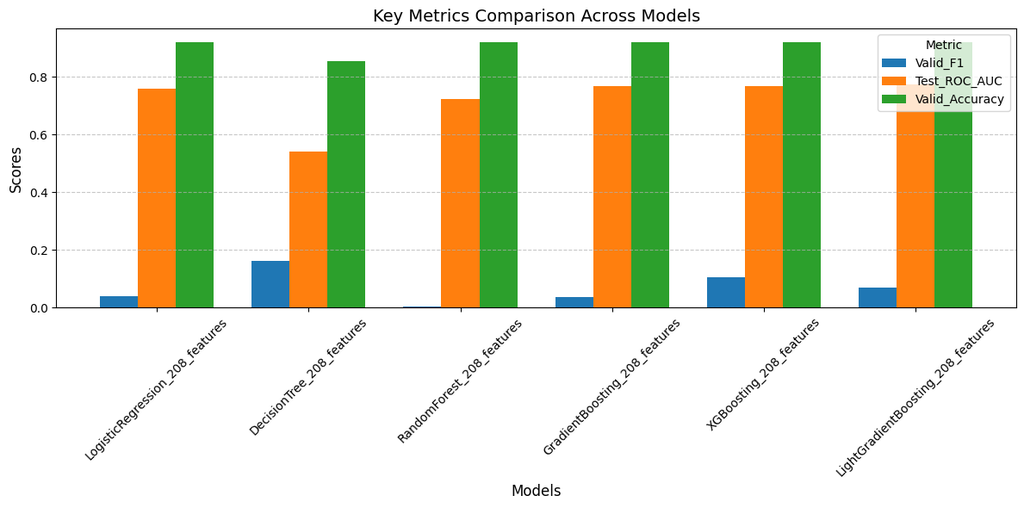

```python
# Metrics to plot
metrics_to_plot = ["Valid_F1", "Test_ROC_AUC", "Valid_Accuracy"]

# Create the plot
fig, ax = plt.subplots(figsize=(12, 6))

# X-axis positions for the models
x = np.arange(len(expLog["Experiment_Name"]))

# Bar width
width = 0.25

# Plot each metric
for i, metric in enumerate(metrics_to_plot):
    ax.bar(x + i * width, expLog[metric], width, label=metric)

# Add plot details
ax.set_xlabel("Models", fontsize=12)
ax.set_ylabel("Scores", fontsize=12)
ax.set_title("Key Metrics Comparison Across Models", fontsize=14)
ax.set_xticks(x + width)
ax.set_xticklabels(expLog["Experiment_Name"], rotation=45)
ax.legend(title="Metric", fontsize=10)
ax.grid(axis="y", linestyle="--", alpha=0.7)

# Optimize layout and display the plot
plt.tight_layout()
plt.show()
```

Building on these results, we turn our focus to feature selection, aiming to refine the dataset by identifying and retaining the most informative features, which could further enhance model performance.

# 5. Feature Selection

In this phase of the project, we addressed the challenge of high dimensionality in our dataset, which originally consisted of 208 features. Feature selection is a critical step to improve model efficiency, reduce overfitting, and enhance interpretability. We employed a combination of techniques, including **correlation analysis**, **decision trees**, **random forests**, and **Principal Component Analysis (PCA)**, to identify and retain the most relevant features. These methods allowed us to reduce the dataset to the 20 most impactful features while preserving predictive performance. The selected features were then used in subsequent modeling experiments to evaluate their effect on overall model performance.

## 5.1 Feature Selection Exploration

### **5.1.1 PCA**

We performed Principal Component Analysis (PCA) on our dataset, aiming to reduce dimensionality while retaining 95% of the variance. We applied PCA to extract principal components and calculated the variance each component explains, identifying the optimal number of components needed to preserve the desired variance threshold. We also visualized the explained variance through a Scree Plot and a Cumulative Variance Plot.

```python
from sklearn.decomposition import PCA
def perform_pca_analysis(X, n_components=0.95):
    """
    Perform PCA analysis with missing value imputation, plot key PCA graphs,
    and suggest a good cutoff point for the number of principal components.
    """
    # Handle missing values
    imputer = SimpleImputer(strategy='mean')
    X_imputed = imputer.fit_transform(X)

    # Standardize the data
    scaler = StandardScaler()
    X_scaled = scaler.fit_transform(X_imputed)

    # Fit PCA with n_components=0.95 to retain 95% of variance
    pca = PCA(n_components=n_components, svd_solver='full', random_state=42)
    X_pca = pca.fit_transform(X_scaled)

    # Step 4: Explained variance analysis
    explained_variance_ratio = pca.explained_variance_ratio_
    cumulative_variance = np.cumsum(explained_variance_ratio)

    # Print suggested cutoff point
    cutoff_point = np.argmax(cumulative_variance >= n_components) + 1
    print(f"Suggested number of components to retain {n_components*100:.0f}% variance: {cutoff_point}")

    # Bar plot of explained variance by each component (Scree Plot)
    plt.figure(figsize=(12, 6))
    plt.bar(range(1, len(explained_variance_ratio) + 1), explained_variance_ratio, alpha=0.7, align='center', label='Individual Explained Variance')
    plt.xlabel('Principal Component Index')
    plt.ylabel('Explained Variance Ratio')
    plt.title('Scree Plot: Variance Explained by PCA Components')
    plt.legend(loc='best')
    plt.show()

    # Cumulative variance explained plot
    plt.figure(figsize=(12, 6))
    plt.plot(range(1, len(cumulative_variance) + 1), cumulative_variance, marker='o', label='Cumulative Variance Explained')
    plt.axhline(y=n_components, color='r', linestyle='--', label=f'{n_components*100:.0f}% Variance Explained Threshold')
    plt.xlabel('Number of Components')
    plt.ylabel('Cumulative Variance')
    plt.title('Cumulative Variance Explained by PCA Components')
    plt.legend(loc='best')
    plt.grid()
    plt.show()

    # Pairplot of first 3 PCA components
    if X_pca.shape[1] >= 3:
        pca_df = pd.DataFrame(X_pca[:, :3], columns=['PC1', 'PC2', 'PC3'])
        sns.pairplot(pca_df)
        plt.suptitle('Pairplot of First Three Principal Components', y=1.02)
        plt.show()

    return pca, X_pca
```

```
Suggested number of components to retain 95% variance: 108
```

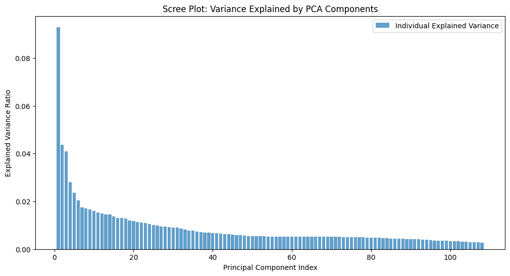

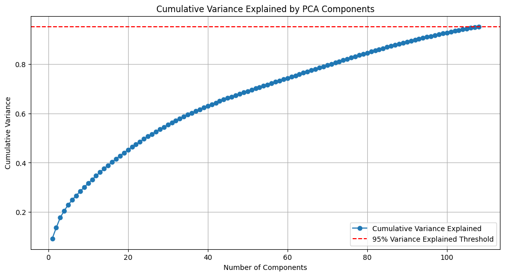

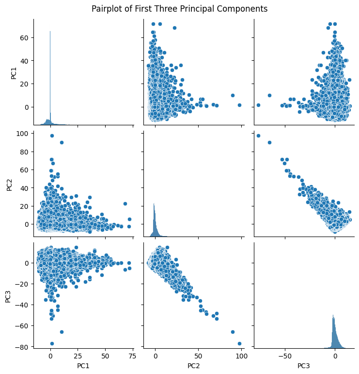

```
Individual Variance Contributions for Top Components:
-----------------------------------------------------
Principal Component 1: 0.0930 (9.30%)
Principal Component 2: 0.0436 (4.36%)
Principal Component 3: 0.0410 (4.10%)
Principal Component 4: 0.0280 (2.80%)
Principal Component 5: 0.0236 (2.36%)
Principal Component 6: 0.0204 (2.04%)
Principal Component 7: 0.0174 (1.74%)
Principal Component 8: 0.0170 (1.70%)
Principal Component 9: 0.0166 (1.66%)
Principal Component 10: 0.0159 (1.59%)
Principal Component 11: 0.0154 (1.54%)
Principal Component 12: 0.0149 (1.49%)

Total Explained Variance by Top 12 Components: 0.3469 (34.69%)
```

```python
# Run PCA on numerical features
X_numerical = X_train[numerical_features]
pca, X_train_pca = perform_pca_analysis(X_numerical)

# Check if PCA was performed and if explained_variance_ratio_ is accessible
if hasattr(pca, "explained_variance_ratio_"):
    total_variance_explained = 0
    n_top_components = 12  # Customize the number of components to analyze

    print("\nIndividual Variance Contributions for Top Components:")
    print("-----------------------------------------------------")
    for j in range(min(n_top_components, len(pca.explained_variance_ratio_))):  # Safeguard against index errors
        contribution = pca.explained_variance_ratio_[j]
        print(f"Principal Component {j+1}: {contribution:.4f} ({contribution*100:.2f}%)")
        total_variance_explained += contribution

    print(f"\nTotal Explained Variance by Top {n_top_components} Components: {total_variance_explained:.4f} ({total_variance_explained*100:.2f}%)")
else:
    print("PCA failed or explained_variance_ratio_ is not available.")
```

If we aim to retain 95% variance, we'll need far more than 12 components, suggesting PCA alone may not simplify the dataset sufficiently for modeling.

We need to investigate if some features are irrelevant or redundant. We need to do a correlation analysis to check for highly correlated features that might be contributing redundancy and explore feature importance, which might help PCA perform better.

```python
# Add PCA to preprocessing pipeline
numerical_transformer = Pipeline(steps=[
    ('imputer', SimpleImputer(strategy='mean')),
    ('scaler', StandardScaler()),
    ('pca', PCA(n_components=pca.n_components_))
])

preprocessor = ColumnTransformer(
    transformers=[
        ('num', numerical_transformer, numerical_features),
        ('cat', categorical_transformer, categorical_features)
    ]
)

# Define models
pca_models = {
    "LogisticRegression": LogisticRegression(random_state=42)
}

# Create pipelines
pipelines = {}
for model_name, model in pca_models.items():
    pipelines[model_name] = Pipeline(steps=[
        ('preprocessor', preprocessor),
        ('model', pca_models[model_name])
    ])
```

```python
# Train and evaluate models
%%time
best_models = {}
for model_name, pipeline in pipelines.items():
    print(f"Training {model_name}...")
    pipeline.fit(X_train, y_train)
    best_models[model_name] = pipeline
```

```
Training LogisticRegression...
CPU times: user 14.3 s, sys: 6.6 s, total: 20.9 s
Wall time: 5.2 s
```

```python
# Evaluation
for model_name, model in best_models.items():
    y_pred = model.predict(X_test)
    print(f"\n{model_name} Performance:")
    print(f"Accuracy: {accuracy_score(y_test, y_pred):.4f}")
    print(classification_report(y_test, y_pred))
```

```
LogisticRegression Performance:
Accuracy: 0.9160
              precision    recall  f1-score   support

           0       0.92      1.00      0.96     35915
           1       0.50      0.02      0.03      3293

    accuracy                           0.92     39208
   macro avg       0.71      0.51      0.49     39208
weighted avg       0.88      0.92      0.88     39208
```

### **5.1.2 Correlation Analysis**

To begin addressing the high dimensionality and redundancy in the dataset, we will perform a correlation analysis. This step will help us identify features that are highly correlated with each other, potentially contributing redundant information.

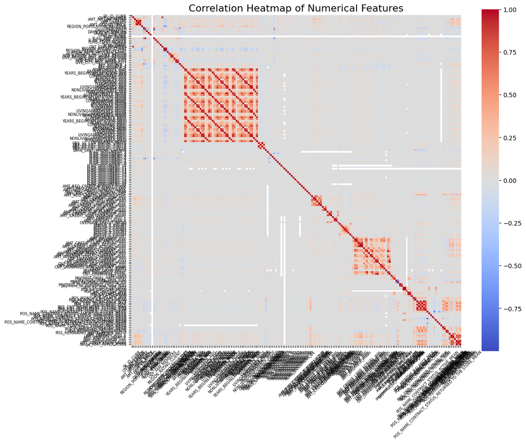

```
Highly correlated features (|correlation| > 0.9):
('AMT_GOODS_PRICE', 'AMT_CREDIT')
('FLOORSMIN_MEDI', 'FLOORSMIN_MODE')
('POS_SK_DPD_DEF_MEAN', 'POS_SK_DPD_DEF_MAX')
('BASEMENTAREA_MODE', 'BASEMENTAREA_AVG')
('POS_CNT_INSTALMENT_FUTURE_SIZE', 'POS_CNT_INSTALMENT_SIZE')
('LIVINGAREA_AVG', 'APARTMENTS_AVG')
('BASEMENTAREA_MEDI', 'BASEMENTAREA_AVG')
('NONLIVINGAREA_MEDI', 'NONLIVINGAREA_MODE')
('COMMONAREA_MODE', 'COMMONAREA_AVG')
('LIVINGAPARTMENTS_MODE', 'APARTMENTS_AVG')
('NONLIVINGAPARTMENTS_MODE', 'NONLIVINGAPARTMENTS_AVG')
('APARTMENTS_MEDI', 'LIVINGAPARTMENTS_AVG')
('FLOORSMIN_MODE', 'FLOORSMIN_AVG')
('LIVINGAPARTMENTS_MEDI', 'LIVINGAPARTMENTS_AVG')
('TOTALAREA_MODE', 'LIVINGAREA_AVG')
('YEARS_BEGINEXPLUATATION_MODE', 'YEARS_BEGINEXPLUATATION_AVG')
('POS_CNT_INSTALMENT_FUTURE_MAX', 'POS_CNT_INSTALMENT_MAX')
('COMMONAREA_MEDI', 'COMMONAREA_AVG')
('FLOORSMAX_MEDI', 'FLOORSMAX_AVG')
('LIVINGAREA_MEDI', 'LIVINGAREA_MODE')
('FLAG_EMP_PHONE', 'DAYS_EMPLOYED')
('ENTRANCES_MEDI', 'ENTRANCES_AVG')
('YEARS_BUILD_MEDI', 'YEARS_BUILD_MODE')
('FLOORSMIN_MEDI', 'FLOORSMIN_AVG')
('LIVINGAPARTMENTS_MODE', 'APARTMENTS_MODE')
('ELEVATORS_MODE', 'ELEVATORS_AVG')
('APARTMENTS_MEDI', 'APARTMENTS_AVG')
('COMMONAREA_MEDI', 'COMMONAREA_MODE')
('ELEVATORS_MEDI', 'ELEVATORS_AVG')
('LIVINGAPARTMENTS_MEDI', 'APARTMENTS_AVG')
('YEARS_BUILD_MODE', 'YEARS_BUILD_AVG')
('NONLIVINGAREA_MODE', 'NONLIVINGAREA_AVG')
('ENTRANCES_MEDI', 'ENTRANCES_MODE')
('REGION_RATING_CLIENT_W_CITY', 'REGION_RATING_CLIENT')
('NONLIVINGAPARTMENTS_MEDI', 'NONLIVINGAPARTMENTS_MODE')
('LIVINGAREA_MEDI', 'APARTMENTS_AVG')
('LANDAREA_MODE', 'LANDAREA_AVG')
('APARTMENTS_MODE', 'LIVINGAPARTMENTS_AVG')
('YEARS_BUILD_MEDI', 'YEARS_BUILD_AVG')
```

[output cut: 18 more lines]

```
('ELEVATORS_MEDI', 'ELEVATORS_MODE')
('APARTMENTS_MEDI', 'LIVINGAPARTMENTS_MODE')
('LIVINGAPARTMENTS_MEDI', 'LIVINGAPARTMENTS_MODE')
('LIVINGAREA_MODE', 'APARTMENTS_MODE')
('LIVINGAREA_MEDI', 'APARTMENTS_MEDI')
('LIVINGAREA_MEDI', 'LIVINGAREA_AVG')
('APARTMENTS_MODE', 'APARTMENTS_AVG')
('POS_SK_DPD_MEAN', 'POS_SK_DPD_MAX')
('LIVINGAPARTMENTS_MODE', 'LIVINGAPARTMENTS_AVG')
('YEARS_BEGINEXPLUATATION_MEDI', 'YEARS_BEGINEXPLUATATION_AVG')
('LIVINGAREA_MODE', 'LIVINGAREA_AVG')
('NONLIVINGAREA_MEDI', 'NONLIVINGAREA_AVG')
('TOTALAREA_MODE', 'LIVINGAREA_MEDI')
('BASEMENTAREA_MEDI', 'BASEMENTAREA_MODE')
('ENTRANCES_MODE', 'ENTRANCES_AVG')
```

```python
# Compute the correlation matrix for numerical features
correlation_matrix = X_train[numerical_features].corr()

# Plot the heatmap to visualize correlations
plt.figure(figsize=(12, 10))
sns.heatmap(correlation_matrix, annot=False, cmap='coolwarm', cbar=True, square=True, fmt='.2f',
            xticklabels=True, yticklabels=True, annot_kws={"size": 5})
plt.title('Correlation Heatmap of Numerical Features', fontsize=16)

# Adjust font size for tick labels
plt.xticks(fontsize=6, rotation=45)
plt.yticks(fontsize=6, rotation=0)

plt.show()

# Identify highly correlated features
high_correlation_threshold = 0.9  # Define a threshold for high correlation
correlated_features = set()

for i in range(len(correlation_matrix.columns)):
    for j in range(i):
        if abs(correlation_matrix.iloc[i, j]) > high_correlation_threshold:
            colname1 = correlation_matrix.columns[i]
            colname2 = correlation_matrix.columns[j]
            correlated_features.add((colname1, colname2))

print(f"Highly correlated features (|correlation| > {high_correlation_threshold}):")
for pair in correlated_features:
    print(pair)
```

Based on the correlation analysis, we identified several pairs of features with extremely high correlations (|correlation| > 0.9), indicating significant redundancy in the dataset. For instance, features such as `NONLIVINGAREA_MEDI` and `NONLIVINGAREA_MODE`, and `APARTMENTS_MEDI` and `LIVINGAREA_AVG`, show almost identical relationships, suggesting that one feature in each highly correlated pair may be unnecessary. To address this, we should remove or merge redundant features. This preprocessing step could make PCA more effective.